# Part II - (Presentation On Prosper Loan Data )

## by (Paul Boadu Asamoah)

## Investigation Overview

In this analysis, I will explore the factors and patterns in the creditworthiness of borrowers and the borrowing trend of Prosper Loan Business.

## Dataset Overview

This data set contains 113,937 loans with 81 variables on each loan, including loan amount, borrower rate (or interest rate), current loan status, borrower income, and many others.

## The distribution of borrowers Loan Status

The Loan Status distribution provides information on the number of borrowers in various categories, such as those who has completed their loan, those who are still servicing it, and those who have defaulted, charged off, or cancelled their loan.

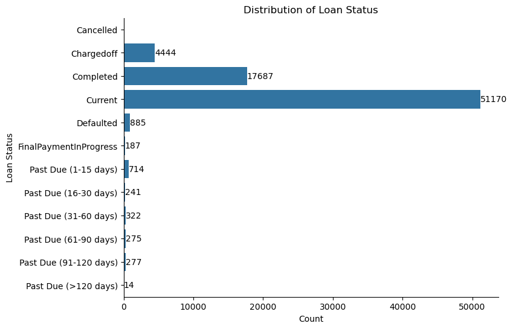

## Prosper Rating vs Is Borrower Homeowner

There are a sizable proportion of borrowers are rated C, with a relatively even split between those who own a home and those who do not. Borrowers with an A credit score are more common, with a higher percentage owning a home. Borrowers with an AA credit rating are relatively uncommon, and the majority own a home. This information suggests that more research into IsBorrowerHomeowner is necessary.

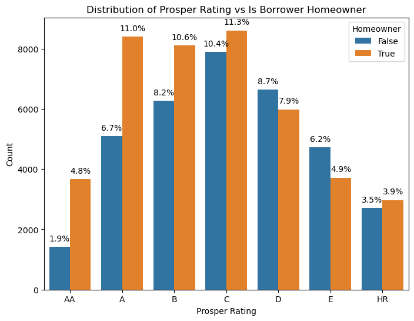

## Trend of Monthly Loan Payment by Term of Loan over the Years

The evolution of loan terms of the business demonstrats that the company initially offered only 36-month loan terms before introducing 12-month and 60-month terms in 2010. There is a significant and steady increase in the monthly loan payment since the introduction of the 12-month loan term, which has continued until 2013. Similarly, the 36-month loan term has seen consistent increases in loan payments from 2009 to the present.

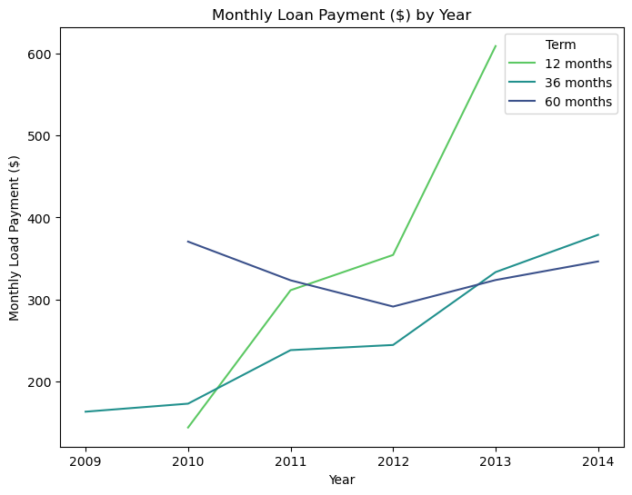

## Relationship Between LoanOriginalAmount and MonthlyLoanPayment Over EmploymentStatus

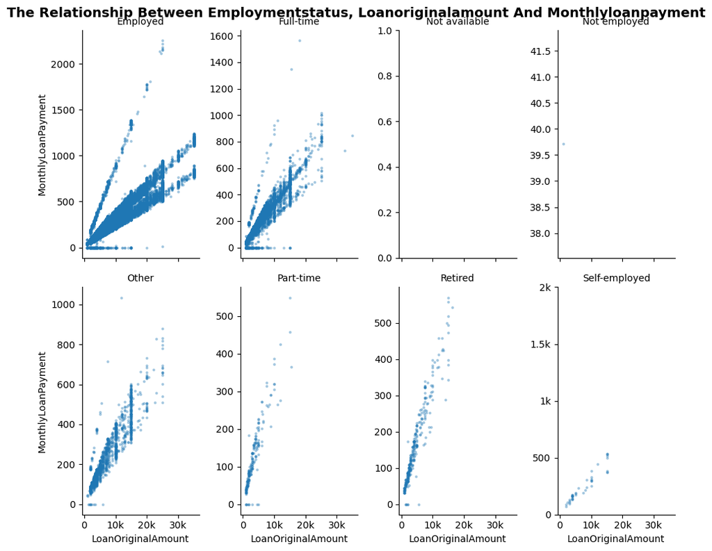